# Hotel Booking Cancellations

2022-12-20

# Exploratory Data Analysis

Let’s load the data.

```r
load("data/bookings_train.Rdata")
load("data/bookings_test.Rdata")
load("data/bookings_test_solutions.Rdata")
```

Now let’s run some exploratory analysis.

```r
bookings_train |> count(is_cancelled) |>
  mutate(prop = n / sum(n))
```

```
## # A tibble: 2 × 3
##   is_cancelled     n  prop
##   <fct>        <int> <dbl>
## 1 yes           6673 0.278
## 2 no           17362 0.722
```

```r
skim(bookings_train) |> knit_print ()
```

Data summary

| Name | bookings_train |
| --- | --- |
| Number of rows | 24035 |
| Number of columns | 26 |
| _______________________ |  |
| Column type frequency: |  |
| character | 4 |
| factor | 5 |
| numeric | 17 |
| ________________________ |  |
| Group variables | None |

**Variable type: character**

| skim_variable | n_missing | complete_rate | min | max | empty | n_unique | whitespace |
| --- | --- | --- | --- | --- | --- | --- | --- |
| arrival_date_month | 0 | 1 | 3 | 9 | 0 | 12 | 0 |
| country | 0 | 1 | 2 | 4 | 0 | 115 | 0 |
| reserved_room_type | 0 | 1 | 1 | 1 | 0 | 10 | 0 |
| assigned_room_type | 0 | 1 | 1 | 1 | 0 | 10 | 0 |

**Variable type: factor**

| skim_variable | n_missing | complete_rate | ordered | n_unique | top_counts |
| --- | --- | --- | --- | --- | --- |
| is_cancelled | 0 | 1 | FALSE | 2 | no: 17362, yes: 6673 |
| meal | 0 | 1 | FALSE | 5 | BB: 18062, HB: 4771, Und: 703, FB: 449 |
| market_segment | 0 | 1 | FALSE | 5 | Onl: 10688, Off: 4487, Dir: 3888, Gro: 3479 |
| deposit_type | 0 | 1 | FALSE | 3 | No : 22946, Non: 1014, Ref: 75 |
| customer_type | 0 | 1 | FALSE | 4 | Tra: 18151, Tra: 4662, Con: 1043, Gro: 179 |

**Variable type: numeric**

| skim_variable | n_missing | complete_rate | mean | sd | p0 | p25 | p50 | p75 | p100 | hist |
| --- | --- | --- | --- | --- | --- | --- | --- | --- | --- | --- |
| lead_time | 0 | 1 | 92.74 | 97.60 | 0.00 | 10 | 57 | 155.00 | 737 | ▇▂▁▁▁ |
| arrival_date_year | 0 | 1 | 2016.12 | 0.72 | 2015.00 | 2016 | 2016 | 2017.00 | 2017 | ▃▁▇▁▆ |
| arrival_date_week_number | 0 | 1 | 27.12 | 13.97 | 1.00 | 16 | 28 | 38.00 | 53 | ▆▇▇▇▆ |
| arrival_date_day_of_month | 0 | 1 | 15.79 | 8.89 | 1.00 | 8 | 16 | 24.00 | 31 | ▇▇▇▆▆ |
| stays_in_weekend_nights | 0 | 1 | 1.19 | 1.15 | 0.00 | 0 | 1 | 2.00 | 16 | ▇▁▁▁▁ |
| stays_in_week_nights | 0 | 1 | 3.13 | 2.48 | 0.00 | 1 | 3 | 5.00 | 40 | ▇▁▁▁▁ |
| adults | 0 | 1 | 1.87 | 0.75 | 0.00 | 2 | 2 | 2.00 | 55 | ▇▁▁▁▁ |
| children | 0 | 1 | 0.13 | 0.44 | 0.00 | 0 | 0 | 0.00 | 3 | ▇▁▁▁▁ |
| babies | 0 | 1 | 0.01 | 0.12 | 0.00 | 0 | 0 | 0.00 | 2 | ▇▁▁▁▁ |
| is_repeated_guest | 0 | 1 | 0.04 | 0.21 | 0.00 | 0 | 0 | 0.00 | 1 | ▇▁▁▁▁ |
| previous_cancellations | 0 | 1 | 0.10 | 1.36 | 0.00 | 0 | 0 | 0.00 | 26 | ▇▁▁▁▁ |
| previous_bookings_not_cancelled | 0 | 1 | 0.15 | 1.00 | 0.00 | 0 | 0 | 0.00 | 30 | ▇▁▁▁▁ |
| booking_changes | 0 | 1 | 0.28 | 0.71 | 0.00 | 0 | 0 | 0.00 | 16 | ▇▁▁▁▁ |
| days_in_waiting_list | 0 | 1 | 0.52 | 7.37 | 0.00 | 0 | 0 | 0.00 | 185 | ▇▁▁▁▁ |
| adr | 0 | 1 | 94.58 | 61.17 | -6.38 | 50 | 75 | 124.21 | 450 | ▇▅▂▁▁ |
| required_car_parking_spaces | 0 | 1 | 0.14 | 0.35 | 0.00 | 0 | 0 | 0.00 | 3 | ▇▁▁▁▁ |
| total_of_special_requests | 0 | 1 | 0.62 | 0.81 | 0.00 | 0 | 0 | 1.00 | 5 | ▇▁▁▁▁ |

```r
#undefined meals exist
#roughly the same amount of bookings all year round
#stays in weekend nights and week nights correlated?
#some outliers here from there on out - children, babies, adults, repeated guest, previous cancellations, booking changes etc.
#there is a negative average daily rate? - also this one has a different distribution
#someone with 185 days on the waiting list and 26 previous cancellations

#is repeated guest should be a factor variable, not a numeric oone
bookings_train$is_repeated_guest <- as.factor(bookings_train$is_repeated_guest)
#the average of babies is 0.01 - propose to merge it with children
#majority of previous bookings and previous bookings not cancelled equal to zero
#the character variables could probably be set to type factor for the regressions
```

```r
cor(bookings_train$stays_in_week_nights,bookings_train$stays_in_weekend_nights)
```

```
## [1] 0.7150746
```

```r
#may be useful to combine somehow or drop one
```

```r
bookings_train |> group_by(is_cancelled) |>
  skim() |> yank("numeric") |> knit_print()
```

**Variable type: numeric**

| skim_variable | is_cancelled | n_missing | complete_rate | mean | sd | p0 | p25 | p50 | p75 | p100 | hist |
| --- | --- | --- | --- | --- | --- | --- | --- | --- | --- | --- | --- |
| lead_time | yes | 0 | 1 | 130.01 | 99.25 | 0.00 | 45 | 111 | 200.00 | 471.00 | ▇▅▃▁▁ |
| lead_time | no | 0 | 1 | 78.41 | 93.07 | 0.00 | 5 | 37 | 130.00 | 737.00 | ▇▂▁▁▁ |
| arrival_date_year | yes | 0 | 1 | 2016.18 | 0.72 | 2015.00 | 2016 | 2016 | 2017.00 | 2017.00 | ▃▁▇▁▆ |
| arrival_date_year | no | 0 | 1 | 2016.10 | 0.72 | 2015.00 | 2016 | 2016 | 2017.00 | 2017.00 | ▃▁▇▁▅ |
| arrival_date_week_number | yes | 0 | 1 | 27.52 | 12.76 | 1.00 | 18 | 29 | 37.00 | 53.00 | ▃▆▇▇▃ |
| arrival_date_week_number | no | 0 | 1 | 26.96 | 14.40 | 1.00 | 15 | 28 | 39.00 | 53.00 | ▆▇▇▇▆ |
| arrival_date_day_of_month | yes | 0 | 1 | 15.62 | 8.96 | 1.00 | 8 | 16 | 24.00 | 31.00 | ▇▆▆▆▆ |
| arrival_date_day_of_month | no | 0 | 1 | 15.85 | 8.87 | 1.00 | 8 | 16 | 24.00 | 31.00 | ▇▇▇▇▆ |
| stays_in_weekend_nights | yes | 0 | 1 | 1.35 | 1.16 | 0.00 | 0 | 1 | 2.00 | 16.00 | ▇▁▁▁▁ |
| stays_in_weekend_nights | no | 0 | 1 | 1.14 | 1.14 | 0.00 | 0 | 1 | 2.00 | 16.00 | ▇▁▁▁▁ |
| stays_in_week_nights | yes | 0 | 1 | 3.45 | 2.51 | 0.00 | 2 | 3 | 5.00 | 40.00 | ▇▁▁▁▁ |
| stays_in_week_nights | no | 0 | 1 | 3.01 | 2.46 | 0.00 | 1 | 2 | 5.00 | 40.00 | ▇▁▁▁▁ |
| adults | yes | 0 | 1 | 1.97 | 1.21 | 0.00 | 2 | 2 | 2.00 | 55.00 | ▇▁▁▁▁ |
| adults | no | 0 | 1 | 1.83 | 0.47 | 0.00 | 2 | 2 | 2.00 | 4.00 | ▁▂▇▁▁ |
| children | yes | 0 | 1 | 0.19 | 0.54 | 0.00 | 0 | 0 | 0.00 | 2.00 | ▇▁▁▁▁ |
| children | no | 0 | 1 | 0.11 | 0.40 | 0.00 | 0 | 0 | 0.00 | 3.00 | ▇▁▁▁▁ |
| babies | yes | 0 | 1 | 0.01 | 0.10 | 0.00 | 0 | 0 | 0.00 | 1.00 | ▇▁▁▁▁ |
| babies | no | 0 | 1 | 0.02 | 0.13 | 0.00 | 0 | 0 | 0.00 | 2.00 | ▇▁▁▁▁ |
| previous_cancellations | yes | 0 | 1 | 0.36 | 2.55 | 0.00 | 0 | 0 | 0.00 | 26.00 | ▇▁▁▁▁ |
| previous_cancellations | no | 0 | 1 | 0.01 | 0.11 | 0.00 | 0 | 0 | 0.00 | 5.00 | ▇▁▁▁▁ |
| previous_bookings_not_cancelled | yes | 0 | 1 | 0.02 | 0.27 | 0.00 | 0 | 0 | 0.00 | 10.00 | ▇▁▁▁▁ |
| previous_bookings_not_cancelled | no | 0 | 1 | 0.20 | 1.16 | 0.00 | 0 | 0 | 0.00 | 30.00 | ▇▁▁▁▁ |
| booking_changes | yes | 0 | 1 | 0.15 | 0.56 | 0.00 | 0 | 0 | 0.00 | 16.00 | ▇▁▁▁▁ |
| booking_changes | no | 0 | 1 | 0.34 | 0.75 | 0.00 | 0 | 0 | 0.00 | 13.00 | ▇▁▁▁▁ |
| days_in_waiting_list | yes | 0 | 1 | 0.11 | 3.16 | 0.00 | 0 | 0 | 0.00 | 125.00 | ▇▁▁▁▁ |
| days_in_waiting_list | no | 0 | 1 | 0.68 | 8.44 | 0.00 | 0 | 0 | 0.00 | 185.00 | ▇▁▁▁▁ |
| adr | yes | 0 | 1 | 105.50 | 65.54 | 0.00 | 56 | 83 | 143.43 | 450.00 | ▇▅▂▁▁ |
| adr | no | 0 | 1 | 90.38 | 58.87 | -6.38 | 48 | 72 | 117.97 | 426.25 | ▇▅▂▁▁ |
| required_car_parking_spaces | yes | 0 | 1 | 0.00 | 0.00 | 0.00 | 0 | 0 | 0.00 | 0.00 | ▁▁▇▁▁ |
| required_car_parking_spaces | no | 0 | 1 | 0.19 | 0.40 | 0.00 | 0 | 0 | 0.00 | 3.00 | ▇▂▁▁▁ |
| total_of_special_requests | yes | 0 | 1 | 0.48 | 0.76 | 0.00 | 0 | 0 | 1.00 | 5.00 | ▇▁▁▁▁ |
| total_of_special_requests | no | 0 | 1 | 0.67 | 0.83 | 0.00 | 0 | 0 | 1.00 | 5.00 | ▇▁▁▁▁ |

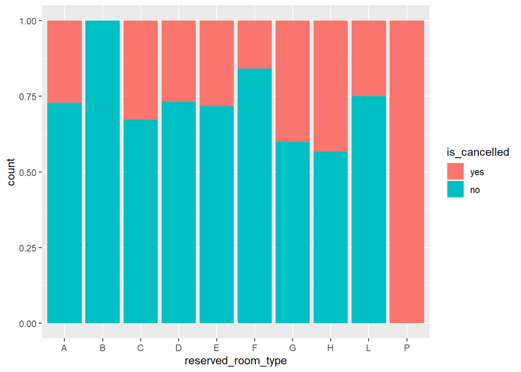

```r
ggplot(data = bookings_train, aes(x = reserved_room_type, fill = is_cancelled)) + geom_bar(position = "fill")#rooms G and H seem to have higher cancellation rate
```

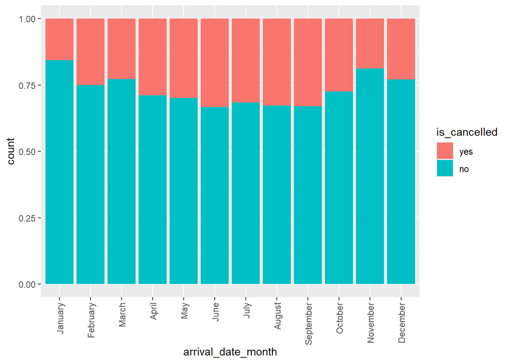

```r
bookings_train$arrival_date_month <- factor(bookings_train$arrival_date_month,levels = month.name)
ggplot(data = bookings_train, aes(x = arrival_date_month, fill = is_cancelled)) + geom_bar(position = "fill") + theme(axis.text.x=element_text(angle=90,hjust=1,vjust=0.5)) #seems to be a division between summer and winter months, but this might be be because there is an imbalance of bookings?
```

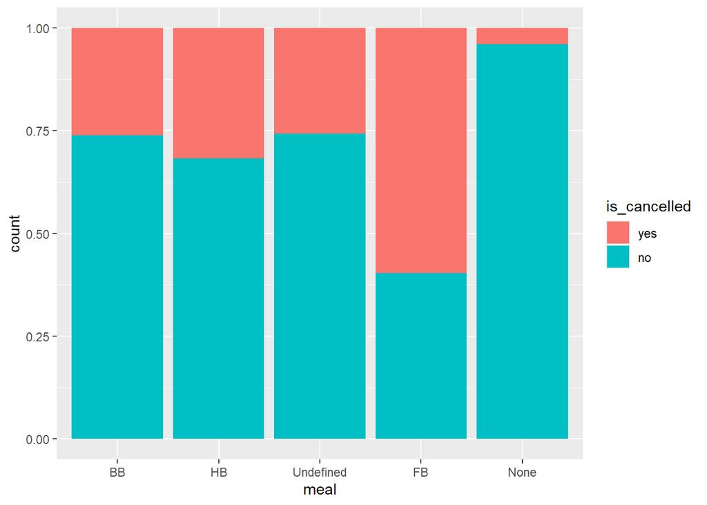

```r
ggplot(data = bookings_train, aes(x = meal, fill = is_cancelled)) + geom_bar(position = "fill") #FB has a lot of cancellations compared to the rest, none has almost none
```

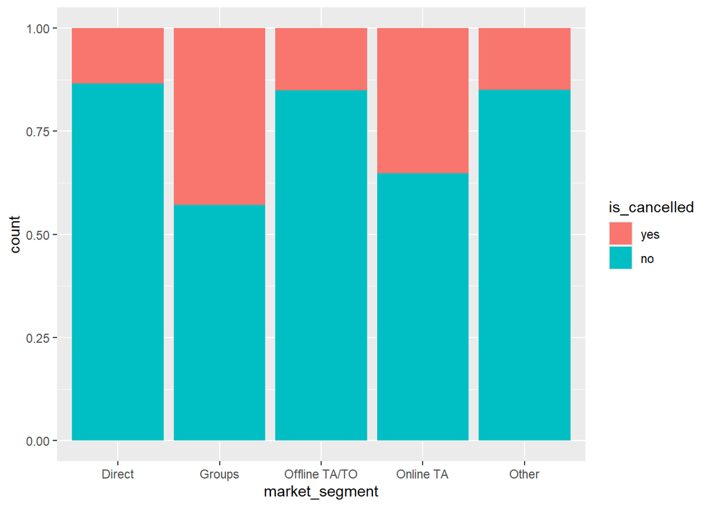

```r
ggplot(data = bookings_train, aes(x = market_segment, fill = is_cancelled)) + geom_bar(position = "fill") #big difference between groups and online TAs and the rest
```

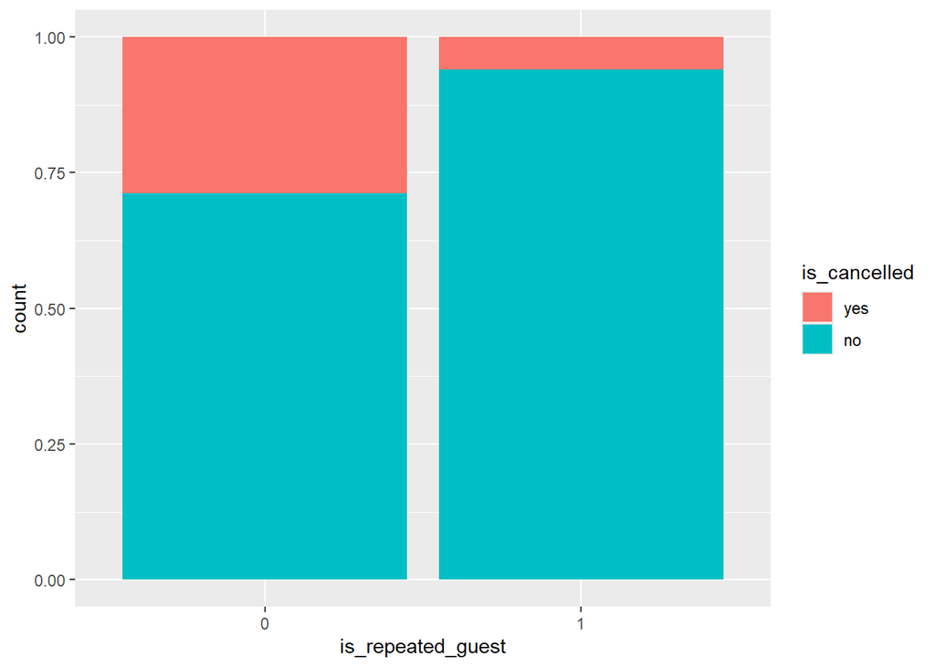

```r
ggplot(data = bookings_train, aes(x = is_repeated_guest, fill = is_cancelled)) + geom_bar(position = "fill") #repeated guests understandably have lower cancellation rates
```

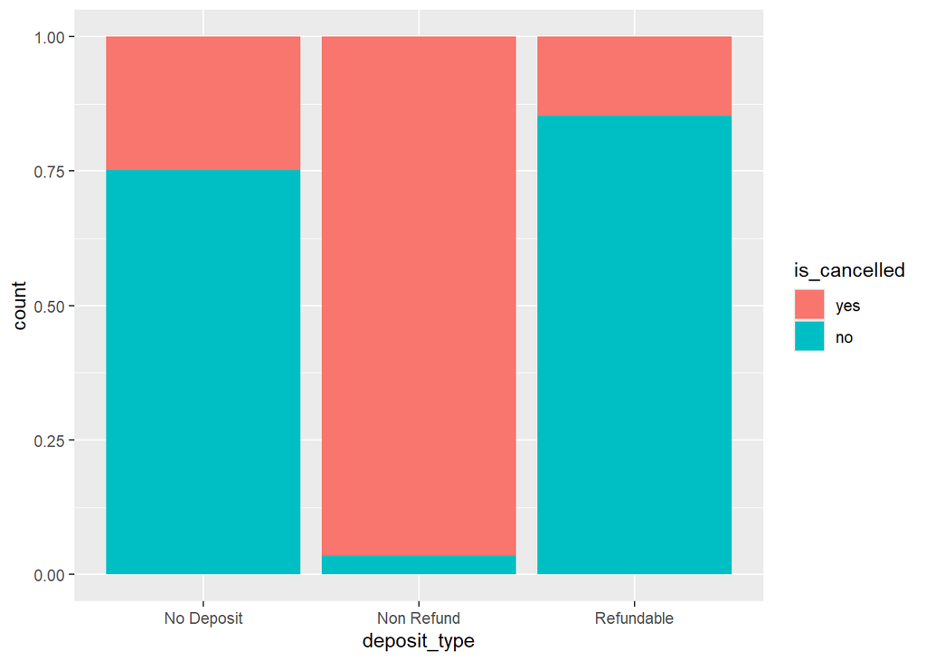

```r
ggplot(data = bookings_train, aes(x = deposit_type, fill = is_cancelled)) + geom_bar(position = "fill") #non refundable have a lot of cancellations???why
```

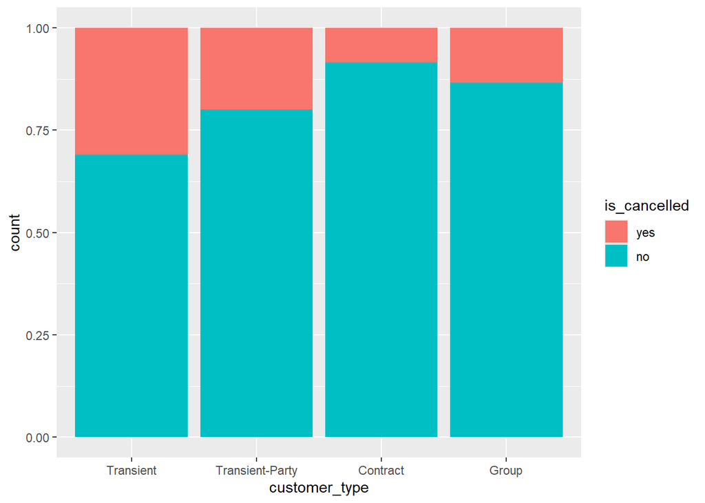

```r
ggplot(data = bookings_train, aes(x = customer_type, fill = is_cancelled)) + geom_bar(position = "fill")#transients have significantly higher cancellations
```

# Data Cleaning and Feature Engineering

```r
## Preprocessing
#removing observations
bookings_train <- filter(bookings_train, bookings_train$adults != 0)

#add up the different nights since they have high correlation
bookings_train <- bookings_train |> mutate(total_stay_nights=stays_in_week_nights+stays_in_weekend_nights)
#remove 0 night stays
bookings_train <- filter(bookings_train, total_stay_nights != 0)

bookings_train <- filter(bookings_train, bookings_train$adr > 0)

## Feature engineering
#differing between external and internal tourism
bookings_train <- bookings_train |> mutate(Regional = case_when(country == "PRT" ~ "Internal", country != "PRT" ~ "External"))

#whether they got assigned different rooms or not
bookings_train <- bookings_train |> mutate(Different_Room = case_when(reserved_room_type == assigned_room_type ~ 0, reserved_room_type != assigned_room_type ~ 1))

#removing reserved room type since it is mostly similar to assigned room type
bookings_train <- subset(bookings_train, select = c(-reserved_room_type))

#add a weekend variable
bookings_train$is_weekend <- ifelse(bookings_train$stays_in_weekend_nights > 0, 1, 0)

#remove weekend, weeknights
bookings_train <- subset(bookings_train, select = c(-stays_in_week_nights, - stays_in_weekend_nights))

#combine children and babies
bookings_train <- bookings_train |> mutate(total_children=children+babies)
bookings_train <- subset(bookings_train, select = c(-children, - babies))

#separating seasons
bookings_train <- bookings_train |> mutate(season = case_when(arrival_date_month %in% c("April","May","June","July","August","September","October") ~ 1, arrival_date_month %in% c("January","February","March","November","December") ~ 0))
```

We also turn the following variables into categorical (factor) variables.

```r
bookings_train$arrival_date_year <- as.factor(bookings_train$arrival_date_year)
bookings_train$arrival_date_month <- as.factor(bookings_train$arrival_date_month)
bookings_train$arrival_date_week_number <- as.factor(bookings_train$arrival_date_week_number)
bookings_train$arrival_date_day_of_month <- as.factor(bookings_train$arrival_date_day_of_month)
bookings_train$assigned_room_type <- as.factor(bookings_train$assigned_room_type)
bookings_train$Regional <- as.factor(bookings_train$Regional)
bookings_train$Different_Room <- as.factor(bookings_train$Different_Room)
bookings_train$is_weekend <- as.factor(bookings_train$is_weekend)
bookings_train$season <- as.factor(bookings_train$season)
bookings_train$is_repeated_guest <- as.factor(bookings_train$is_repeated_guest)


skim(bookings_train) |> knit_print ()
```

Data summary

| Name | bookings_train |
| --- | --- |
| Number of rows | 23565 |
| Number of columns | 27 |
| _______________________ |  |
| Column type frequency: |  |
| character | 1 |
| factor | 15 |
| numeric | 11 |
| ________________________ |  |
| Group variables | None |

**Variable type: character**

| skim_variable | n_missing | complete_rate | min | max | empty | n_unique | whitespace |
| --- | --- | --- | --- | --- | --- | --- | --- |
| country | 0 | 1 | 2 | 4 | 0 | 114 | 0 |

**Variable type: factor**

| skim_variable | n_missing | complete_rate | ordered | n_unique | top_counts |
| --- | --- | --- | --- | --- | --- |
| is_cancelled | 0 | 1 | FALSE | 2 | no: 16953, yes: 6612 |
| arrival_date_year | 0 | 1 | FALSE | 3 | 201: 10959, 201: 7792, 201: 4814 |
| arrival_date_month | 0 | 1 | FALSE | 12 | Aug: 2904, Jul: 2681, Apr: 2157, May: 2113 |
| arrival_date_week_number | 0 | 1 | FALSE | 53 | 33: 693, 34: 663, 30: 634, 31: 631 |
| arrival_date_day_of_month | 0 | 1 | FALSE | 31 | 12: 916, 2: 873, 30: 846, 16: 844 |
| meal | 0 | 1 | FALSE | 5 | BB: 17713, HB: 4710, Und: 682, FB: 443 |
| market_segment | 0 | 1 | FALSE | 5 | Onl: 10561, Off: 4422, Dir: 3805, Gro: 3413 |
| is_repeated_guest | 0 | 1 | FALSE | 2 | 0: 22582, 1: 983 |
| assigned_room_type | 0 | 1 | FALSE | 9 | A: 10086, D: 6128, E: 3346, C: 1331 |
| deposit_type | 0 | 1 | FALSE | 3 | No : 22476, Non: 1014, Ref: 75 |
| customer_type | 0 | 1 | FALSE | 4 | Tra: 17809, Tra: 4561, Con: 1035, Gro: 160 |
| Regional | 0 | 1 | FALSE | 2 | Ext: 13332, Int: 10233 |
| Different_Room | 0 | 1 | FALSE | 2 | 0: 19151, 1: 4414 |
| is_weekend | 0 | 1 | FALSE | 2 | 1: 15484, 0: 8081 |
| season | 0 | 1 | FALSE | 2 | 1: 15596, 0: 7969 |

**Variable type: numeric**

| skim_variable | n_missing | complete_rate | mean | sd | p0 | p25 | p50 | p75 | p100 | hist |
| --- | --- | --- | --- | --- | --- | --- | --- | --- | --- | --- |
| lead_time | 0 | 1 | 93.45 | 97.45 | 0.0 | 11 | 59.0 | 155 | 709 | ▇▂▁▁▁ |
| adults | 0 | 1 | 1.86 | 0.44 | 1.0 | 2 | 2.0 | 2 | 4 | ▂▇▁▁▁ |
| previous_cancellations | 0 | 1 | 0.11 | 1.37 | 0.0 | 0 | 0.0 | 0 | 26 | ▇▁▁▁▁ |
| previous_bookings_not_cancelled | 0 | 1 | 0.15 | 1.00 | 0.0 | 0 | 0.0 | 0 | 30 | ▇▁▁▁▁ |
| booking_changes | 0 | 1 | 0.28 | 0.69 | 0.0 | 0 | 0.0 | 0 | 16 | ▇▁▁▁▁ |
| days_in_waiting_list | 0 | 1 | 0.48 | 6.94 | 0.0 | 0 | 0.0 | 0 | 185 | ▇▁▁▁▁ |
| adr | 0 | 1 | 96.46 | 60.29 | 1.8 | 52 | 76.5 | 126 | 450 | ▇▃▁▁▁ |
| required_car_parking_spaces | 0 | 1 | 0.14 | 0.35 | 0.0 | 0 | 0.0 | 0 | 3 | ▇▁▁▁▁ |
| total_of_special_requests | 0 | 1 | 0.62 | 0.81 | 0.0 | 0 | 0.0 | 1 | 5 | ▇▁▁▁▁ |
| total_stay_nights | 0 | 1 | 4.38 | 3.39 | 1.0 | 2 | 4.0 | 7 | 56 | ▇▁▁▁▁ |
| total_children | 0 | 1 | 0.14 | 0.46 | 0.0 | 0 | 0.0 | 0 | 3 | ▇▁▁▁▁ |

# Model Assessment Setup

Regarding the metrics, we chose to go with accuracy and sensitivity, as these were metrics that the hotel management expressed interest in. We also chose Cohen’s Kappa as an additional metric, as from the exploratory data analysis, we found that there are almost three times as many non-cancellations compared to cancellations. This metric helps us adjust accuracy for the chance of making a correct prediction by chance alone, which could be relatively high given the imbalance of dependent variables in the data set. Furthermore, we also included specificity as a metric, since we concluded that is overall more costly for the hotel if the model predicts cancellation but there is none (high false positives - opposite of true negatives), since this may lead to lower levels of customer service (understaffed hotels, not enough rooms).

```r
set.seed(9125)
bookings_train_split <- initial_split(data = bookings_train, prop = 0.75,
                          strata = is_cancelled)
bookings_train2 <- training(bookings_train_split)
bookings_val <- testing(bookings_train_split)

#testing whether the proportion of dependent variables stayed the same
bookings_train2 |> count(is_cancelled) |>
  mutate(prop = n / sum(n))
```

```
## # A tibble: 2 × 3
##   is_cancelled     n  prop
##   <fct>        <int> <dbl>
## 1 yes           4959 0.281
## 2 no           12714 0.719
```

```r
bookings_val |> count(is_cancelled) |>
  mutate(prop = n / sum(n))
```

```
## # A tibble: 2 × 3
##   is_cancelled     n  prop
##   <fct>        <int> <dbl>
## 1 yes           1653 0.281
## 2 no            4239 0.719
```

Additionally, we will also use 10-fold cross-validation to perform tuning on our models to select the best performing hyperparameters. We still stratify on the is_cancelled dependent variable.

```r
set.seed(7357)
cv_folds <- bookings_train2 |> vfold_cv(v = 10, strata = is_cancelled)
```

Once our models are tuned, we can then compare their performance on our “validation” set bookings_val. Whichever model performs the best on this validation set will then be used on the final test set, which the hotel manager will provide.

## Setting up the recipe

In this section we also set up the recipe, since this remains (almost) the same across the models. We are including all the independent variables we have in our data post-exploratory analysis and feature engineering, as predictors in our models. Additionally:

To deal with the class imbalance, here we chose to also test a recipe with downsampled data (based on the variable we want to predict) version.

```r
recipe_downsample <- recipe(is_cancelled ~ ., data = bookings_train2) |>
  update_role(country, new_role = "metadata") |>
  step_normalize(all_numeric()) |>
  step_downsample(is_cancelled)

recipe_regular <- recipe(is_cancelled ~ ., data = bookings_train2) |>
  update_role(country, new_role = "metadata") |>
  step_normalize(all_numeric())
```

# Random Forests

```r
rf_model_tune <- rand_forest(mtry = tune(), trees = 500) |>
  set_mode("classification") |>
  set_engine("ranger")
```

## Workflow for tuning

Let us combine the recipe and the model into a workflow to be tuned:

```r
rf_tune_wf <- workflow() |>
  add_recipe(recipe_regular) |>
  add_model(rf_model_tune)
rf_tune_wf
```

```
## ══ Workflow ════════════════════════════════════════════════════════════════════
## Preprocessor: Recipe
## Model: rand_forest()
##
## ── Preprocessor ────────────────────────────────────────────────────────────────
## 1 Recipe Step
##
## • step_normalize()
##
## ── Model ───────────────────────────────────────────────────────────────────────
## Random Forest Model Specification (classification)
##
## Main Arguments:
##   mtry = tune()
##   trees = 500
##
## Computational engine: ranger
```

```r
rf_tune_wf_ds <- workflow() |>
  add_recipe(recipe_downsample) |>
  add_model(rf_model_tune)
```

## Tuning

Here we choose to do the tuning for m-values between 5 and 15 (we tried multiple ranges and this one ended up being the most sensible, while capturing the desired results). *Note*: when downsampling in the pre-processing recipe, the sensitivity of the model increased considerably (around 15% or so), while the other metrics decreased only marginally.

```r
registerDoParallel(cores = 6)
```

Here, we define our metrics and tune the model.

```r
# these are metrics we defined above
class_metrics <- metric_set(accuracy, kap, sensitivity,
                            specificity, roc_auc)

set.seed(99154345)
rf_tune_res <- tune_grid(
  rf_tune_wf,
  resamples = cv_folds,
  grid = tibble(mtry = 5:15),
  metrics = class_metrics
)

set.seed(99154345)
rf_tune_res_ds <- tune_grid(
  rf_tune_wf_ds,
  resamples = cv_folds,
  grid = tibble(mtry = 5:15),
  metrics = class_metrics
)
```

Now we run a few plots to assess the model’s performance.

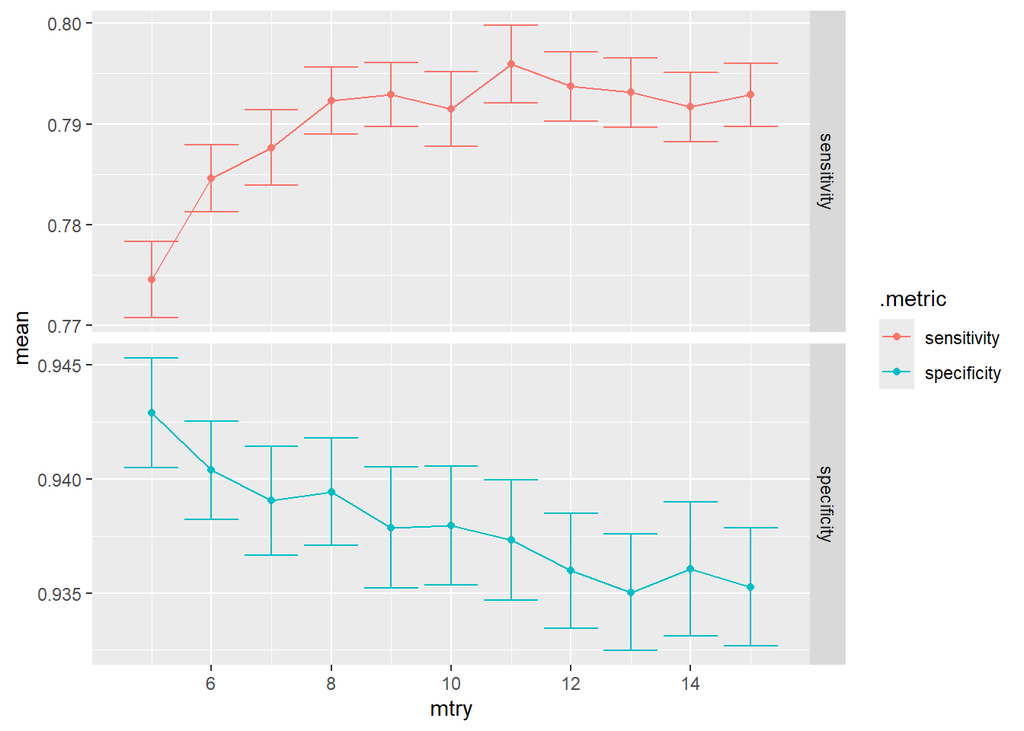

```r
rf_tune_res |>
  collect_metrics() |>
  filter(.metric %in% c("sensitivity", "specificity")) |>
  ggplot(aes(x = mtry, y = mean, ymin = mean - std_err, ymax = mean + std_err,
             colour = .metric)) +
  geom_errorbar() +
  geom_line() +
  geom_point() +
  facet_grid(.metric ~ ., scales = "free_y")
```

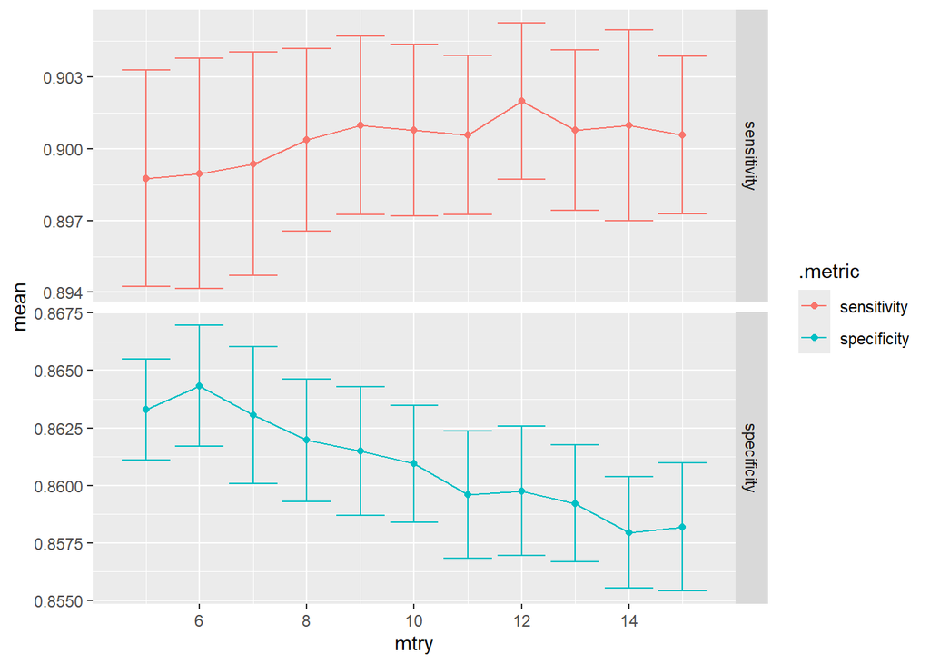

```r
rf_tune_res_ds |>
  collect_metrics() |>
  filter(.metric %in% c("sensitivity", "specificity")) |>
  ggplot(aes(x = mtry, y = mean, ymin = mean - std_err, ymax = mean + std_err,
             colour = .metric)) +
  geom_errorbar() +
  geom_line() +
  geom_point() +
  facet_grid(.metric ~ ., scales = "free_y")
```

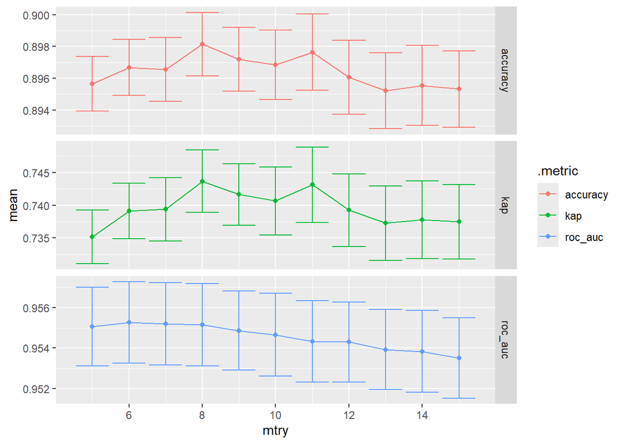

```r
rf_tune_res |>
  collect_metrics() |>
  filter(.metric %in% c("roc_auc", "accuracy", "kap")) |>
  ggplot(aes(x = mtry, y = mean, ymin = mean - std_err, ymax = mean + std_err,
             colour = .metric)) +
  geom_errorbar() +
  geom_line() +
  geom_point() +
  facet_grid(.metric ~ ., scales = "free_y")
```

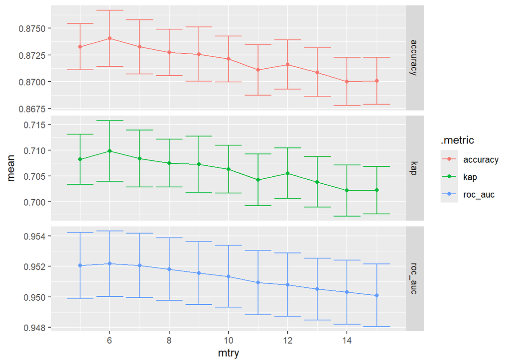

```r
rf_tune_res_ds |>
  collect_metrics() |>
  filter(.metric %in% c("roc_auc", "accuracy", "kap")) |>
  ggplot(aes(x = mtry, y = mean, ymin = mean - std_err, ymax = mean + std_err,
             colour = .metric)) +
  geom_errorbar() +
  geom_line() +
  geom_point() +
  facet_grid(.metric ~ ., scales = "free_y")
```

## Test (“validation”) set performance

```r
# select the best parameters based on the accuracy metric
best_acc <- select_best(rf_tune_res_ds, metric = "accuracy")
rf_final_wf <- finalize_workflow(rf_tune_wf_ds, best_acc)
rf_final_wf
```

```
## ══ Workflow ════════════════════════════════════════════════════════════════════
## Preprocessor: Recipe
## Model: rand_forest()
##
## ── Preprocessor ────────────────────────────────────────────────────────────────
## 2 Recipe Steps
##
## • step_normalize()
## • step_downsample()
##
## ── Model ───────────────────────────────────────────────────────────────────────
## Random Forest Model Specification (classification)
##
## Main Arguments:
##   mtry = 6
##   trees = 500
##
## Computational engine: ranger
```

```r
set.seed(9923)
rf_final_fit <- rf_final_wf |>
  last_fit(bookings_train_split, metrics = class_metrics)

rf_final_fit |>
  collect_metrics()
```

```
## # A tibble: 5 × 4
##   .metric     .estimator .estimate .config
##   <chr>       <chr>          <dbl> <chr>
## 1 accuracy    binary         0.880 Preprocessor1_Model1
## 2 kap         binary         0.724 Preprocessor1_Model1
## 3 sensitivity binary         0.914 Preprocessor1_Model1
## 4 specificity binary         0.867 Preprocessor1_Model1
## 5 roc_auc     binary         0.956 Preprocessor1_Model1
```

```r
rf_final_fit |> collect_predictions() |>
  conf_mat(truth = is_cancelled, estimate = .pred_class)
```

```
##           Truth
## Prediction  yes   no
##        yes 1511  565
##        no   142 3674
```

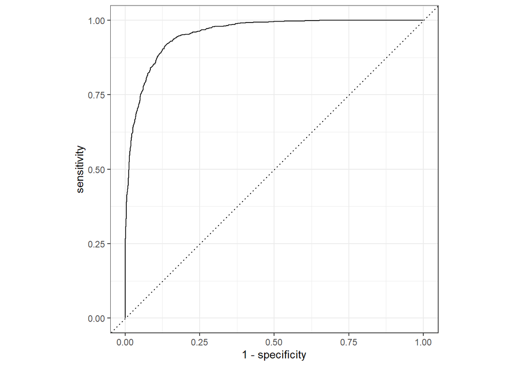

```r
rf_final_fit |> collect_predictions() |>
  roc_curve(is_cancelled, .pred_yes) |>
  autoplot()
```

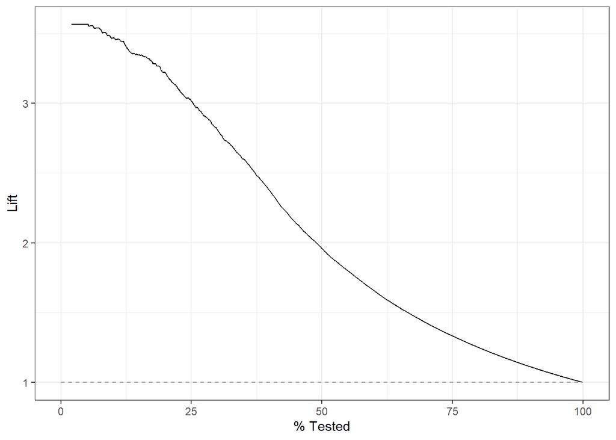

```r
rf_final_fit |> collect_predictions() |>
  lift_curve(is_cancelled, .pred_yes) |>
  autoplot()
```

For communication with stakeholders, we plot out the variable importance here, as determined by the random forest algorithm:

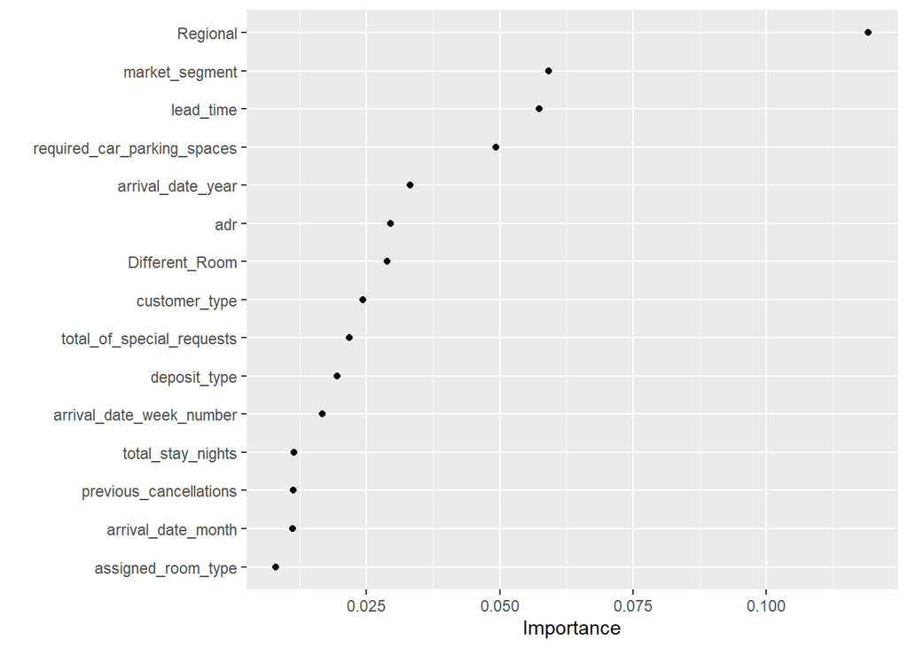

```r
# here we plot out the importance of the features as determined by our random forest algorithm
rf_model_vi <- rand_forest(mtry = 6, trees = 500) |>
  set_mode("classification") |>
  set_engine("ranger", importance = "permutation")

rf_vi_wf <- workflow() |>
  add_model(rf_model_vi) |>
  add_recipe(recipe_downsample)

set.seed(9923)
rf_vi_fit <- rf_vi_wf |> fit(data = bookings_train2)

rf_vi_fit |> extract_fit_parsnip() |> vip(geom = "point", num_features = 15)
```

# Regularized logistic regression

The first thing to do is to create a workflow using the recipes defined earlier.

```r
recipe_regular <- recipe(is_cancelled ~ ., data = bookings_train2) |>
  update_role(country, new_role = "metadata") |>
  step_normalize(all_numeric()) |>
  step_dummy(all_nominal()&all_predictors()) |>
  step_downsample(is_cancelled)

bookings_train2_baked <- recipe_regular |> prep(bookings_train2) |> bake(bookings_train2)
head(bookings_train2_baked)
```

```
## # A tibble: 6 × 134
##   lead_time adults country previous_cancellations previous_bookings_not_cancel…¹
##       <dbl>  <dbl> <fct>                    <dbl>                          <dbl>
## 1     0.725  0.315 ESP                    -0.0776                         -0.146
## 2     0.797  0.315 POL                    -0.0776                         -0.146
## 3     1.41   0.315 NLD                    -0.0776                         -0.146
## 4     0.499  0.315 GBR                    -0.0776                         -0.146
## 5    -0.363  0.315 LTU                    -0.0776                         -0.146
## 6     0.962  0.315 PRT                    -0.0776                         -0.146
## # ℹ abbreviated name: ¹previous_bookings_not_cancelled
## # ℹ 129 more variables: booking_changes <dbl>, days_in_waiting_list <dbl>,
## #   adr <dbl>, required_car_parking_spaces <dbl>,
## #   total_of_special_requests <dbl>, total_stay_nights <dbl>,
## #   total_children <dbl>, is_cancelled <fct>, arrival_date_year_X2016 <dbl>,
## #   arrival_date_year_X2017 <dbl>, arrival_date_month_February <dbl>,
## #   arrival_date_month_March <dbl>, arrival_date_month_April <dbl>, …
```

```r
lasso_logreg <- logistic_reg(penalty = tune(), mixture = 1) |>
  set_engine("glmnet")

lasso_wf <- workflow() |>
  add_recipe(recipe_regular) |>
  add_model(lasso_logreg)
```

Now the workflow is defined, a tuning grid needs to be defined so further tuning can be done.

```r
grid_lasso <- tibble(penalty = 10^(seq(from = -4.5, to = -0.5, length.out = 100)))
lasso_tune <- lasso_wf |>
  tune_grid(resamples = cv_folds,
            grid = grid_lasso,
            metrics = class_metrics)
```

Now the lasso function is tuned, let’s look at the accuracy of the model.

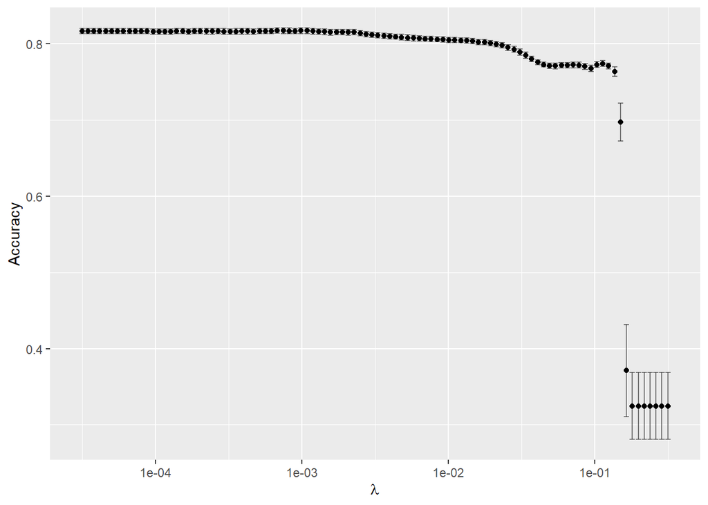

```r
lasso_tune_metrics <- lasso_tune |>
  collect_metrics()
lasso_tune_metrics |> filter(.metric == "accuracy") |>
  ggplot(aes(x = penalty, y = mean,
             ymin = mean - std_err, ymax = mean + std_err)) +
  geom_errorbar(alpha = 0.5) +
  geom_point() +
  scale_x_log10() +
  labs(y = "Accuracy", x = expression(lambda))
```

```r
lasso_1se_model <- lasso_tune |>
  select_by_one_std_err(metric = "accuracy", desc(penalty))
lasso_1se_model
```

```
## # A tibble: 1 × 2
##   penalty .config
##     <dbl> <chr>
## 1 0.00251 Preprocessor1_Model048
```

```r
lasso_wf_tuned <-
  lasso_wf |>
  finalize_workflow(lasso_1se_model)
lasso_wf_tuned
```

```
## ══ Workflow ════════════════════════════════════════════════════════════════════
## Preprocessor: Recipe
## Model: logistic_reg()
##
## ── Preprocessor ────────────────────────────────────────────────────────────────
## 3 Recipe Steps
##
## • step_normalize()
## • step_dummy()
## • step_downsample()
##
## ── Model ───────────────────────────────────────────────────────────────────────
## Logistic Regression Model Specification (classification)
##
## Main Arguments:
##   penalty = 0.00250605096553008
##   mixture = 1
##
## Computational engine: glmnet
```

```r
lasso_last_fit <- lasso_wf_tuned |>
  last_fit(bookings_train_split, metrics = class_metrics)
lasso_test_metrics <- lasso_last_fit |> collect_metrics()
lasso_test_metrics
```

```
## # A tibble: 5 × 4
##   .metric     .estimator .estimate .config
##   <chr>       <chr>          <dbl> <chr>
## 1 accuracy    binary         0.820 Preprocessor1_Model1
## 2 kap         binary         0.603 Preprocessor1_Model1
## 3 sensitivity binary         0.877 Preprocessor1_Model1
## 4 specificity binary         0.798 Preprocessor1_Model1
## 5 roc_auc     binary         0.912 Preprocessor1_Model1
```

# Using the chosen model on the test dataset

At this point, we were provided the labels for the test dataset and could test the performance of our tuned model on “real-life” data.

## Cleaning dataset

Same steps as were applied to our training dataset are replicated here.

```r
#removing observations
bookings_test_solutions <- filter(bookings_test_solutions, bookings_test_solutions$adults != 0)

#add up the different nights since they have high correlation
bookings_test_solutions <- bookings_test_solutions |> mutate(total_stay_nights=stays_in_week_nights+stays_in_weekend_nights)
#remove 0 night stays
bookings_test_solutions <- filter(bookings_test_solutions, total_stay_nights != 0)

bookings_test_solutions <- filter(bookings_test_solutions, bookings_test_solutions$adr > 0)

##creating new variables
#differing between external and internal tourism
bookings_test_solutions <- bookings_test_solutions |> mutate(Regional = case_when(country == "PRT" ~ "Internal", country != "PRT" ~ "External"))

#whether they got assigned different rooms or not
bookings_test_solutions <- bookings_test_solutions |> mutate(Different_Room = case_when(reserved_room_type == assigned_room_type ~ 0, reserved_room_type != assigned_room_type ~ 1))

#removing reserved room type since it is mostly similar to assigned room type
bookings_test_solutions <- subset(bookings_test_solutions, select = c(-reserved_room_type))

#add a weekend variable
bookings_test_solutions$is_weekend <- ifelse(bookings_test_solutions$stays_in_weekend_nights > 0, 1, 0)

#remove weekend, weeknights
bookings_test_solutions <- subset(bookings_test_solutions, select = c(-stays_in_week_nights, - stays_in_weekend_nights))

#combine children and babies
bookings_test_solutions <- bookings_test_solutions |> mutate(total_children=children+babies)
bookings_test_solutions <- subset(bookings_test_solutions, select = c(-children, - babies))

#separating seasons
bookings_test_solutions <- bookings_test_solutions |> mutate(season = case_when(arrival_date_month %in% c("April","May","June","July","August","September","October") ~ 1, arrival_date_month %in% c("January","February","March","November","December") ~ 0))

bookings_test_solutions$arrival_date_year <- as.factor(bookings_test_solutions$arrival_date_year)
bookings_test_solutions$arrival_date_month <- as.factor(bookings_test_solutions$arrival_date_month)
bookings_test_solutions$arrival_date_week_number <- as.factor(bookings_test_solutions$arrival_date_week_number)
bookings_test_solutions$arrival_date_day_of_month <- as.factor(bookings_test_solutions$arrival_date_day_of_month)
bookings_test_solutions$assigned_room_type <- as.factor(bookings_test_solutions$assigned_room_type)
bookings_test_solutions$Regional <- as.factor(bookings_test_solutions$Regional)
bookings_test_solutions$Different_Room <- as.factor(bookings_test_solutions$Different_Room)
bookings_test_solutions$is_weekend <- as.factor(bookings_test_solutions$is_weekend)
bookings_test_solutions$season <- as.factor(bookings_test_solutions$season)
bookings_test_solutions$is_repeated_guest <- as.factor(bookings_test_solutions$is_repeated_guest)
bookings_test_solutions$country <- as.factor(bookings_test_solutions$country)
skim(bookings_test_solutions) |> knit_print ()
```

Data summary

| Name | bookings_test_solutions |
| --- | --- |
| Number of rows | 15742 |
| Number of columns | 27 |
| _______________________ |  |
| Column type frequency: |  |
| factor | 16 |
| numeric | 11 |
| ________________________ |  |
| Group variables | None |

**Variable type: factor**

| skim_variable | n_missing | complete_rate | ordered | n_unique | top_counts |
| --- | --- | --- | --- | --- | --- |
| is_cancelled | 0 | 1 | FALSE | 2 | no: 11316, yes: 4426 |
| arrival_date_year | 0 | 1 | FALSE | 3 | 201: 7225, 201: 5212, 201: 3305 |
| arrival_date_month | 0 | 1 | FALSE | 12 | Aug: 1945, Jul: 1831, Apr: 1390, Oct: 1385 |
| arrival_date_week_number | 0 | 1 | FALSE | 53 | 33: 495, 31: 460, 32: 427, 30: 422 |
| arrival_date_day_of_month | 0 | 1 | FALSE | 31 | 12: 632, 5: 599, 30: 586, 17: 565 |
| meal | 0 | 1 | FALSE | 5 | BB: 11738, HB: 3246, Und: 449, FB: 302 |
| country | 0 | 1 | FALSE | 98 | PRT: 6841, GBR: 2711, ESP: 1575, IRL: 866 |
| market_segment | 0 | 1 | FALSE | 5 | Onl: 6974, Off: 2954, Dir: 2578, Gro: 2314 |
| is_repeated_guest | 0 | 1 | FALSE | 2 | 0: 15085, 1: 657 |
| assigned_room_type | 0 | 1 | FALSE | 10 | A: 6743, D: 4079, E: 2225, C: 848 |
| deposit_type | 0 | 1 | FALSE | 3 | No : 14970, Non: 705, Ref: 67 |
| customer_type | 0 | 1 | FALSE | 4 | Tra: 11849, Tra: 3065, Con: 729, Gro: 99 |
| Regional | 0 | 1 | FALSE | 2 | Ext: 8901, Int: 6841 |
| Different_Room | 0 | 1 | FALSE | 2 | 0: 12831, 1: 2911 |
| is_weekend | 0 | 1 | FALSE | 2 | 1: 10215, 0: 5527 |
| season | 0 | 1 | FALSE | 2 | 1: 10336, 0: 5406 |

**Variable type: numeric**

| skim_variable | n_missing | complete_rate | mean | sd | p0 | p25 | p50 | p75 | p100 | hist |
| --- | --- | --- | --- | --- | --- | --- | --- | --- | --- | --- |
| lead_time | 0 | 1 | 93.40 | 96.89 | 0.00 | 11.0 | 59.00 | 155.00 | 542 | ▇▃▁▁▁ |
| adults | 0 | 1 | 1.86 | 0.44 | 1.00 | 2.0 | 2.00 | 2.00 | 4 | ▂▇▁▁▁ |
| previous_cancellations | 0 | 1 | 0.10 | 1.31 | 0.00 | 0.0 | 0.00 | 0.00 | 26 | ▇▁▁▁▁ |
| previous_bookings_not_cancelled | 0 | 1 | 0.14 | 1.00 | 0.00 | 0.0 | 0.00 | 0.00 | 29 | ▇▁▁▁▁ |
| booking_changes | 0 | 1 | 0.29 | 0.73 | 0.00 | 0.0 | 0.00 | 0.00 | 13 | ▇▁▁▁▁ |
| days_in_waiting_list | 0 | 1 | 0.52 | 7.44 | 0.00 | 0.0 | 0.00 | 0.00 | 185 | ▇▁▁▁▁ |
| adr | 0 | 1 | 97.24 | 61.05 | 0.26 | 52.2 | 77.02 | 127.63 | 508 | ▇▃▁▁▁ |
| required_car_parking_spaces | 0 | 1 | 0.14 | 0.36 | 0.00 | 0.0 | 0.00 | 0.00 | 8 | ▇▁▁▁▁ |
| total_of_special_requests | 0 | 1 | 0.62 | 0.82 | 0.00 | 0.0 | 0.00 | 1.00 | 5 | ▇▁▁▁▁ |
| total_stay_nights | 0 | 1 | 4.35 | 3.33 | 1.00 | 2.0 | 4.00 | 7.00 | 69 | ▇▁▁▁▁ |
| total_children | 0 | 1 | 0.14 | 0.47 | 0.00 | 0.0 | 0.00 | 0.00 | 10 | ▇▁▁▁▁ |

```r
#Removing L observation
bookings_test_solutions <- bookings_test_solutions |> filter(assigned_room_type != "L")
```

## Fit and predict

The model is performed with random forests on the final test set, as it was selected as the optimum technique.

```r
test_preds <- rf_final_wf |> fit(bookings_train) |> predict(bookings_test_solutions)
bookings_test_solutions <- bookings_test_solutions |> bind_cols(test_preds)
regr_metrics <- metric_set(accuracy, specificity, sensitivity, kap)
bookings_test_solutions |> regr_metrics(truth = is_cancelled, estimate = .pred_class)
```

```
## # A tibble: 4 × 3
##   .metric     .estimator .estimate
##   <chr>       <chr>          <dbl>
## 1 accuracy    binary         0.884
## 2 specificity binary         0.875
## 3 sensitivity binary         0.907
## 4 kap         binary         0.731
```

```r
#Confusion matrix
caret::confusionMatrix(data = bookings_test_solutions$is_cancelled, reference = bookings_test_solutions$.pred_class)
```

```
## Confusion Matrix and Statistics
##
##           Reference
## Prediction  yes   no
##        yes 4013  412
##        no  1418 9898
##
##                Accuracy : 0.8837
##                  95% CI : (0.8786, 0.8887)
##     No Information Rate : 0.655
##     P-Value [Acc > NIR] : < 2.2e-16
##
##                   Kappa : 0.731
##
##  Mcnemar's Test P-Value : < 2.2e-16
##
##             Sensitivity : 0.7389
##             Specificity : 0.9600
##          Pos Pred Value : 0.9069
##          Neg Pred Value : 0.8747
##              Prevalence : 0.3450
##          Detection Rate : 0.2549
##    Detection Prevalence : 0.2811
##       Balanced Accuracy : 0.8495
##
##        'Positive' Class : yes
##
```